# Basic Python for Economic Analysis

Inter-American Development Bank Workshop

Diego A. Guerrero

2025-11-23

# Learning Objectives

- Familiarize with the basic concepts of **Python** and **R**
- Identify and manipulate **data structures**
- Run and execute **Python / R scripts**
- Perform **basic data uploading and cleaning**
- Compute **summary statistics** and visualize simple data

# Introduction to Python

**Why?**

- Python is useful due to the speed, reproducibility , flexibility, and an ecosystem of libraries
- Ontegrates with R, SQL, Excel, Sata, and APIs
- Scale: working with a small dataset? Good. Working with Big Data in the cloud? Perfect
- Free

## Introduction to Python

- Install **Anaconda** (includes Python, Jupyter, Pandas, NumPy, etc.)
- Create an environment
- Install libraries in the environment
- Launch **Jupyter Notebook** or **JupyterLab**

## Install **Anaconda**

**Why**: Anaconda bundles Python, conda (env manager), Jupyter, and many data science packages.

#### Steps

1. Go to the Anaconda download page (choose Python 3.x installer) and download for your OS.
2. Run the installer and follow prompts (accept default options is fine for most users).

## Terminal

Open a terminal (Windows) by looking for the Anaconda Prompt terminal.

[figure not shown]

## Verify installation

Open a terminal / Anaconda Prompt and run:

```bash
conda --version
python --version
jupyter --version
```

[figure not shown]

## Create conda environment

**Why**: Keeps project dependencies isolated (safer for reproducibility and error control).

#### Steps

1. Go to the Anaconda Prompt and type:

```bash
conda create -n econ -y
```

2. Activate the environment

```bash
conda activate econ
```

## Libraries

### Install required packages/libraries to run your program

**Why**: Environments come *clean* and you choose the dependencies and libraries that will be run on that project.

```bash
conda activate econ
conda install pandas -y
conda install numpy matplotlib seaborn jupyterlab openpyxl statsmodels scikit-learn -y
```

### Libraries (pip)

Some packages are unavailable in the anaconda network. You install them with `pip`:

```bash
conda activate econ
pip install scikit-learn -y
```

**Tip:** Prefer `conda install` (faster, fewer build issues); use `pip` only when needed.

*(Other packages are far more complex. You may need to download a wheel.)*

### Key Libraries

- [jupyter](https://jupyter.org)
- [pandas](https://pandas.pydata.org/)
- [numpy](https://numpy.org/)
- [matplotlib](https://matplotlib.org/)
- [seaborn](https://seaborn.pydata.org/)
- [openpyxl](https://openpyxl.readthedocs.io/en/stable/)
- [statsmodels](https://www.statsmodels.org/)
- [scikit-learn](https://scikit-learn.org/stable/)

## Ready to Launch!

We will launch python from the Anaconda prompt.

The standard interface is **jupyter lab/notebook** or **jupyter**

*Alternatives: spyder (Scientific Python Development Environment), vscode, PyCharm, Google Colab…*

```bash
conda activate econ
jupyter lab        # modern interface
# or
jupyter notebook   # classic notebook
```

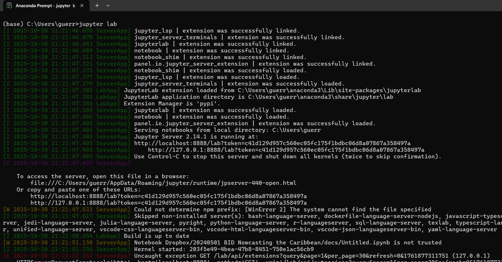

## Jupyter

[figure not shown]

## First python program

Create a Notebook using the python kernel. We are ready to run our first program:

```python
print("Hello world")

print(2+5)
```

```
Hello world
7
```

# Python syntax

## Variables, Types

### What are variables?

Variables store information for later use.

```python
country = "Bahamas"
gdp = 12_500
growth_rate = 0.032
island = True
print(country, gdp)
print(growth_rate, island)
```

```
Bahamas 12500
0.032 True
```

*Warning*: Variables are stored in your RAM

## Data Types

```python
a = 10 # integer
b = 3.14 # float
c = "Economics" # string
d = True # boolean
print(type(a), type(b), type(c), type(d))
```

```
<class 'int'> <class 'float'> <class 'str'> <class 'bool'>
```

**Common types:** - int: whole numbers - float: decimals - str: text - boolean: True/False

## Printing variables as string

```python
country = "Bahamas"
gdp = 12_500
growth_rate = 0.032
island = True
print(f"The country {country} has a GDP of {gdp} \n and a growth rate of {growth_rate*100}\%.")
```

```
The country Bahamas has a GDP of 12500
 and a growth rate of 3.2\%.
```

## Operations

```python
gdp = 12_500
growth_rate = 0.032
gdp_2 = gdp*(1+growth_rate)

print(f"Bahamas grew {growth_rate*100}\% and now has a GDP of {gdp_2}")
```

```
Bahamas grew 3.2\% and now has a GDP of 12900.0
```

```python
# It is a good practice to comment the code.
# We first define the variables
gdp_1 = 12_500
gdp_2 = 12_900

# And we can now calculate the growth rate:
growth = gdp_2/gdp_1 - 1

print(f"The growth rate was {growth*100}\%.")
# Or round up when printing
print( f"The growth rate was {round(growth*100,2)}\%.")
# Or, first define the rounded growth
growth = round(growth,2)
print( f"The growth rate was {growth*100}\%.")
```

```
The growth rate was 3.200000000000003\%.
The growth rate was 3.2\%.
The growth rate was 3.0\%.
```

## Conditional statements

Python includes **relation operators** `(>, <, >=, !=, ==, in, is, not, ~)` that return **booleans** (True/False)

```python
print(5+15 > 10)
print(5 + 15 < 10 )
print(2 >= 5)
print(2 == 4/2)
print("a" != "a")
```

```
True
False
False
True
False
```

We can use `if`, `elif` and `else` with the operators above.

```python
x = "abc"
if type(x) == str :
  print(f"x({x}) is a string")
else :
  print(f"{x} is {type(x)}")
```

```
x(abc) is a string
```

## Conditional statement example

```python
#score = float(input("Enter your exam score: "))
score = 50

if score >= 90:
    print("Grade: A")
elif score >= 80:
    print("Grade: B")
elif score >= 70:
    print("Grade: C")
elif score >= 60:
    print("Grade: D")
else:
    print("Grade: F")

print("Program finished.")
```

```
Grade: F
Program finished.
```

## Data structures (collections)

Data structures organize and store **multiple values** efficiently.  
They are different from simple variables that hold only one value.

| Structure | Example | Key Features |
| --- | --- | --- |
| **List** | `[1, 2, 3]` | Ordered, *mutable* |
| **Tuple** | `(1, 2, 3)` | Ordered, *immutable* |
| **Dictionary** | `{"name": "Ana", "age": 30}` | Key–value pairs |
| **Set** | `{1, 2, 3}` | Unordered, unique elements |

## Loops

- `for`: iterate over a sequence (list, tuple, dictionary, string, range).

```python
fruits = ["apple", "banana", "cherry"]
for fruit in fruits:
    print(fruit)
```

```
apple
banana
cherry
```

- `while`: Repeats as long as a condition is true.

```python
count = 0
while count < 5:
    print("Count is:", count)
    count += 1
```

```
Count is: 0
Count is: 1
Count is: 2
Count is: 3
Count is: 4
```

Some useful statements: `break` (stops the loop), `continue` (skips code on that iteration), `pass` (does nothing/placeholder)

### Loops and Conditionals

```python
for num in range(10):
    if num == 8:
        break  # Stop the loop completely
    elif num == 3:
        continue  # Skip number 3
    print(f"Number: {num}")
```

```
Number: 0
Number: 1
Number: 2
Number: 4
Number: 5
Number: 6
Number: 7
```

## Functions

A **function** is a reusable block of code that performs a specific task.  
It helps you avoid repetition and organize your program.

```python
def greet(name):
    """This function greets the person passed in as a parameter."""
    print("Hello,", name)

greet("Diego")
```

```
Hello, Diego
```

`return` sends a value back from the function to the place where the function was called.

### Function uses

Suppose that you want to run a model and save the results in a table, then do a different model and a table. Functions save space.

```python
def make_table(values):
    """Return a list of (index, value) pairs as a simple table."""
    table = []
    for i, v in enumerate(values):
        table.append((i, v))
    return table

data = [200, -15, 100]
result = make_table(data)

print("Index | Value")
print("--------------")
for row in result:
    print(f"{row[0]:5} | {row[1]:6}")
```

```
Index | Value
--------------
    0 |    200
    1 |    -15
    2 |    100
```

## Dataframes

Table-like structure (`pandas` library) with rows/columns

```python
import pandas as pd
data = {
    "Country": ["Brazil", "Bahamas", "Mexico"],
    "GDP": [2.1, 0.015, 1.8],
    "Population": [214, 0.401, 130]
}
df = pd.DataFrame(data)
df
```

|  | Country | GDP | Population |
| --- | --- | --- | --- |
| 0 | Brazil | 2.100 | 214.000 |
| 1 | Bahamas | 0.015 | 0.401 |
| 2 | Mexico | 1.800 | 130.000 |

# Data in python

## Importing

```python
import pandas as pd
brent = pd.read_csv("session_1_files/eia_brent.csv")
# Quick preview
brent.head()
```

|  | date | brent price |
| --- | --- | --- |
| 0 | 1987-05-20 | 18.63 |
| 1 | 1987-05-21 | 18.45 |
| 2 | 1987-05-22 | 18.55 |
| 3 | 1987-05-25 | 18.60 |
| 4 | 1987-05-26 | 18.63 |

### Importing various formats

Pandas supports many ways to import data.

```bash
# Excel file
pd.read_excel("session_1_files/data.xlsx")
# Text file
pd.read_table("session_1_files/data.txt")
```

### Exporting

Saving data is easy.

```bash
import pandas as pd
data = {
    "Country": ["Brazil", "Bahamas", "Mexico"],
    "GDP": [2.1, 0.015, 1.8],
    "Population": [214, 0.401, 130]
}
df = pd.DataFrame(data)

df.to_csv("session_1_files/example.csv", index=False)
df.to_csv("session_1_files/example.txt", sep="\t", index=False)
df.to_excel("session_1_files/example.xlsx", index=False)
df.to_json("session_1_files/example.json", orient="records")
```

### Data Formats

| Format | Structure | Best for | Advantages | Limitations |
| --- | --- | --- | --- | --- |
| **CSV / TXT** | Flat (rows & columns) | Tabular data, spreadsheets | Simple and lightweight Works everywhere Easy to inspect | No nested data No metadata Loses data types |
| **Excel (.xlsx)** | Flat (cells, sheets) | Business / reports | Formatting, formulas Multiple sheets Familiar to most users | Slow Not ideal for automation |
| **JSON** | Hierarchical (nested) | Web data, APIs, configs | Stores complex/nested data Language-independent APIs | Larger files Harder to view in Excel |
| **Parquet / Feather** | Columnar (binary) | Big data, analytics | Very fast I/O Keeps data types Compressed & efficient | Not human-readable Requires Python/R |

## Data exploration

```python
import pandas as pd
df = pd.read_csv("session_1_files/uscensus_trade.csv")

# Show first rows
df.head()

# Show last rows
df.tail()
```

## Data exploration

|  | date | exports USA | imports USA |
| --- | --- | --- | --- |
| 476 | 2024-09-30 | 36.066283 | 368.731802 |
| 477 | 2024-10-31 | 109.539796 | 305.212492 |
| 478 | 2024-11-30 | 219.298712 | 636.946114 |
| 479 | 2024-12-31 | 366.392066 | 520.629852 |
| 480 | 2025-01-31 | 65.009249 | 506.231056 |

## DataFrame Summary

```python
import pandas as pd
df = pd.read_csv("session_1_files/uscensus_trade.csv")

print("====================")
print("Data info:")
print(df.info()) # Column names, data types, missing values

print("====================")
print("Summary stats:")
print(df.describe()) # Summary stats for numeric columns

print("====================")
print("Size:")
print(df.shape) # (rows, columns)

print("====================")
print("Column/Variable names:")
print(df.columns) # List of column names

print("====================")
print("Data types:")
print(df.dtypes) # Data types of each column
```

[output not shown]

### DataFrame: info()

```python
import pandas as pd
df = pd.read_csv("session_1_files/uscensus_trade.csv")
df.info()
```

```
<class 'pandas.core.frame.DataFrame'>
RangeIndex: 481 entries, 0 to 480
Data columns (total 3 columns):
 #   Column       Non-Null Count  Dtype
---  ------       --------------  -----
 0   date         481 non-null    object
 1   exports USA  481 non-null    float64
 2   imports USA  481 non-null    float64
dtypes: float64(2), object(1)
memory usage: 11.4+ KB
```

### DataFrame: describe()

```python
import pandas as pd
df = pd.read_csv("session_1_files/uscensus_trade.csv")
df.describe()
```

|  | exports USA | imports USA |
| --- | --- | --- |
| count | 481.000000 | 481.000000 |
| mean | 45.783287 | 170.553382 |
| std | 44.591570 | 128.572069 |
| min | 5.500000 | 43.200000 |
| 25% | 23.500000 | 65.200000 |
| 50% | 34.800000 | 125.860780 |
| 75% | 52.100000 | 243.605530 |
| max | 381.395095 | 850.473691 |

### Selecting

Suppose your dataset has many columns and you want to see descriptive statistics of only one.

```python
import pandas as pd
df = pd.read_csv("session_1_files/uscensus_trade.csv")
df['exports USA'].describe()
```

```
count    481.000000
mean      45.783287
std       44.591570
min        5.500000
25%       23.500000
50%       34.800000
75%       52.100000
max      381.395095
Name: exports USA, dtype: float64
```

## Indexes

When dealing with time-series it is a good idea to state the preferred index

```python
import pandas as pd
df = pd.read_csv("session_1_files/uscensus_trade.csv")
df.head()
```

|  | date | exports USA | imports USA |
| --- | --- | --- | --- |
| 0 | 1985-01-31 | 154.4 | 59.0 |
| 1 | 1985-02-28 | 73.7 | 43.2 |
| 2 | 1985-03-31 | 47.7 | 43.4 |
| 3 | 1985-04-30 | 25.5 | 57.9 |
| 4 | 1985-05-31 | 38.3 | 68.0 |

### Set Index

When dealing with time-series it is a good idea to state the preferred index

```python
import pandas as pd
df = pd.read_csv(
    "session_1_files/uscensus_trade.csv",
    index_col='date'
    )
df.head()
```

| date | exports USA | imports USA |
| --- | --- | --- |
| 1985-01-31 | 154.4 | 59.0 |
| 1985-02-28 | 73.7 | 43.2 |
| 1985-03-31 | 47.7 | 43.4 |
| 1985-04-30 | 25.5 | 57.9 |
| 1985-05-31 | 38.3 | 68.0 |

## Manage dates

Sometimes we need to make sure a column is read as a date. Use `pd.to_datetime()`

```python
import pandas as pd
df = pd.read_csv(
    "session_1_files/uscensus_trade.csv"
    )

print(f"The column type: {df['date'].dtype}")
df.date = pd.to_datetime(df['date'], format="%Y-%m-%d")
print(f"After transforming: {df['date'].dtype}")
```

```
The column type: object
After transforming: datetime64[ns]
```

Useful when merging/standardizing/visualizing a dataset.

## Simple visualization

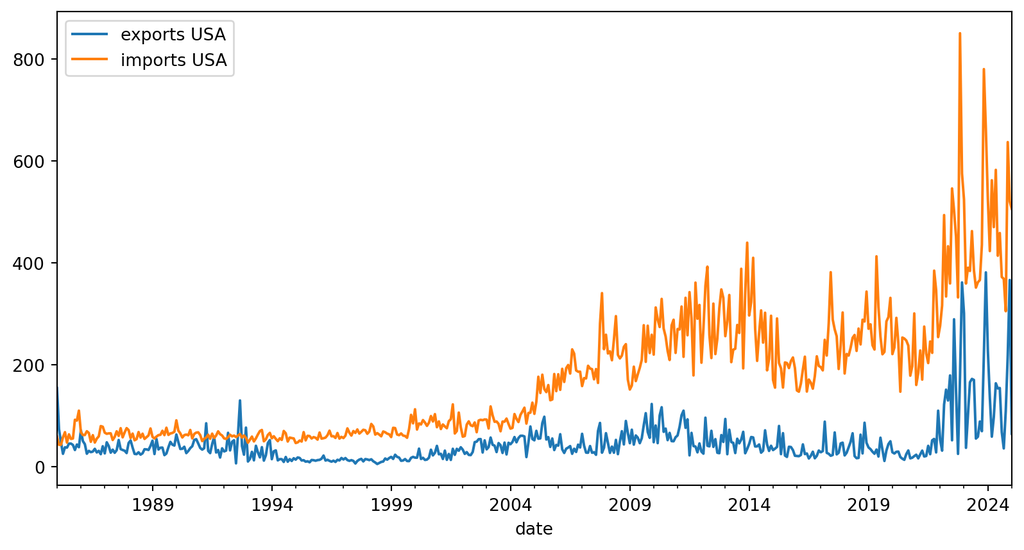

```python
import pandas as pd
df = pd.read_csv(
    "session_1_files/uscensus_trade.csv",
     index_col='date',
     parse_dates=True
     )
df.plot()
```

## Filtering

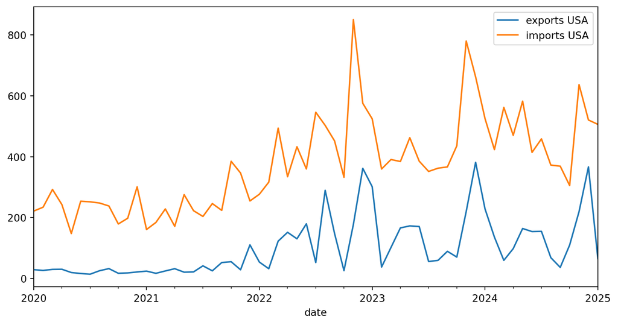

```python
import pandas as pd
df = pd.read_csv(
    "session_1_files/uscensus_trade.csv",
     index_col='date',
     parse_dates=True
     )
df[df.index>"2020-01-01"].plot()
```

### Complex Filtering

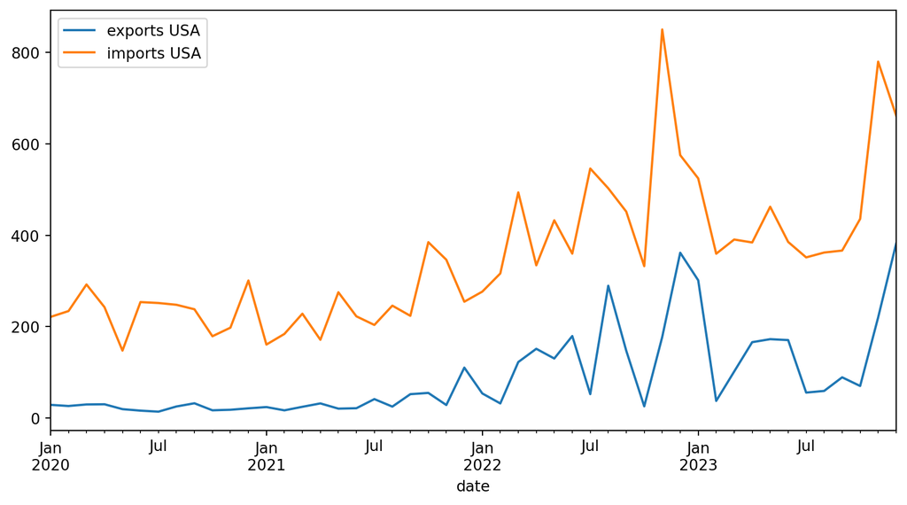

```python
import pandas as pd
df = pd.read_csv(
    "session_1_files/uscensus_trade.csv",
     index_col='date',
     parse_dates=True
     )
df[ (df.index>"2020-01-01") & (df.index<"2024-01-01")].plot()
```

Also `df.loc["2020-01-01":"2025-01-01"].plot()`

## Combining datasets: concat, merge, join

| Method | Typical Use | Based On | Example | Notes |
| --- | --- | --- | --- | --- |
| **`pd.concat()`** | Stack datasets vertically *(rows)* or horizontally *(columns)* | Axis (0 = rows, 1 = cols) | `pd.concat([df1, df2])` | Simple append; doesn’t match keys |
| **`pd.merge()`** | Combine on **one or more columns** (like SQL JOIN) | Key columns | `pd.merge(df1, df2, on="id")` | Most flexible; supports inner, left, right, outer joins |
| **`df.join()`** | Combine on **index** (row labels) | Index alignment | `df1.join(df2)` | Convenient when indices are meaningful |

### concat

|  | id | value | score |
| --- | --- | --- | --- |
| 0 | 1 | A | NaN |
| 1 | 2 | B | NaN |
| 2 | 3 | C | NaN |
| 0 | 2 | NaN | 80.0 |
| 1 | 3 | NaN | 90.0 |
| 2 | 4 | NaN | 70.0 |

### merge

| id | value | score |
| --- | --- | --- |
| 1 | A | NaN |
| 2 | B | 80.0 |
| 3 | C | 90.0 |

### join

| id | value | score |
| --- | --- | --- |
| 1 | A | NaN |
| 2 | B | 80.0 |
| 3 | C | 90.0 |

## Reshaping

### wide → long: melt()

```python
import pandas as pd
df = pd.read_csv(
    "session_1_files/uscensus_trade.csv",
     parse_dates=True
     )

long_df = pd.melt(df, id_vars='date',
                  var_name="Type", value_name="Value")
long_df
```

|  | date | Type | Value |
| --- | --- | --- | --- |
| 0 | 1985-01-31 | exports USA | 154.400000 |
| 1 | 1985-02-28 | exports USA | 73.700000 |
| 2 | 1985-03-31 | exports USA | 47.700000 |
| 3 | 1985-04-30 | exports USA | 25.500000 |
| 4 | 1985-05-31 | exports USA | 38.300000 |
| ... | ... | ... | ... |
| 957 | 2024-09-30 | imports USA | 368.731802 |
| 958 | 2024-10-31 | imports USA | 305.212492 |
| 959 | 2024-11-30 | imports USA | 636.946114 |
| 960 | 2024-12-31 | imports USA | 520.629852 |
| 961 | 2025-01-31 | imports USA | 506.231056 |

962 rows × 3 columns

### Reshaping: long → wide: pivot()

```python
import pandas as pd
df = pd.read_csv(
    "session_1_files/uscensus_trade.csv",
     parse_dates=True
     )

long_df = pd.melt(df, id_vars='date',
                  var_name="Type", value_name="Value")

wide_df = long_df.pivot(index="date", columns="Type", values="Value")
wide_df
```

| Type date | exports USA | imports USA |
| --- | --- | --- |
| 1985-01-31 | 154.400000 | 59.000000 |
| 1985-02-28 | 73.700000 | 43.200000 |
| 1985-03-31 | 47.700000 | 43.400000 |
| 1985-04-30 | 25.500000 | 57.900000 |
| 1985-05-31 | 38.300000 | 68.000000 |
| ... | ... | ... |
| 2024-09-30 | 36.066283 | 368.731802 |
| 2024-10-31 | 109.539796 | 305.212492 |
| 2024-11-30 | 219.298712 | 636.946114 |
| 2024-12-31 | 366.392066 | 520.629852 |
| 2025-01-31 | 65.009249 | 506.231056 |

481 rows × 2 columns

### Reshape: resample()

Transforms data into a different frequency (e.g. daily to monthly/quarterly)

```python
import pandas as pd
import matplotlib.pyplot as plt

# Create a daily dataset
df = pd.read_csv(
    "session_1_files/eia_brent.csv",
    parse_dates= True,
    index_col = "date")

monthly_df = df.resample("M").mean()

plt.figure(figsize=(8,4))
plt.plot(df.index, df["brent price"], alpha=0.4, label="Daily")
plt.plot(monthly_df.index, monthly_df["brent price"], color="red", linewidth=2, label="Monthly")
plt.title("Daily vs. Monthly Brent price", fontsize=14, weight="bold")
plt.legend(frameon=False)
plt.show()
```

### Resample: example

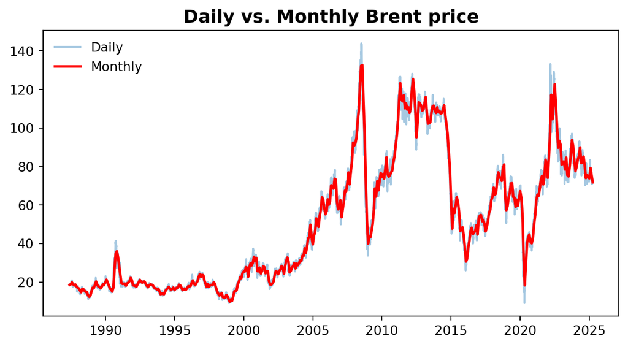

```python
import pandas as pd
import matplotlib.pyplot as plt

# Create a daily dataset
df = pd.read_csv(
    "session_1_files/eia_brent.csv",
    parse_dates= True,
    index_col = "date")

monthly_df = df.resample("M").mean()

plt.figure(figsize=(8,4))
plt.plot(df.index, df["brent price"], alpha=0.4, label="Daily")
plt.plot(monthly_df.index, monthly_df["brent price"], color="red", linewidth=2, label="Monthly")
plt.title("Daily vs. Monthly Brent price", fontsize=14, weight="bold")
plt.legend(frameon=False)
plt.show()
```

### Resample Frequencies

| Code | Frequency | Example Dates |
| --- | --- | --- |
| **“D”** | Daily | 2020-01-01, 2020-01-02 |
| **“W”** | Week-End | 2020-01-05, 2020-01-12 |
| **“M”** | Month-End | 2020-01-31, 2020-02-29 |
| **“MS”** | Month-Start | 2020-01-01, 2020-02-01 |
| **“Q”** | Quarter-End | 2020-03-31, 2020-06-30 |
| **“QS”** | Quarter-Start | 2020-01-01, 2020-04-01 |
| **“A”** | Year-End | 2020-12-31, 2021-12-31 |
| **“AS”** | Year-Start | 2020-01-01, 2021-01-01 |

### Aggregation functions

| Function | Description | Example |
| --- | --- | --- |
| `.mean()` | Average over the period | `df.resample("M").mean()` |
| `.sum()` | Total over the period | `df.resample("M").sum()` |
| `.last()` | Last observation | `df.resample("M").last()` |
| `.first()` | First observation | `df.resample("M").first()` |
| `.max()` | Maximum value | `df.resample("M").max()` |
| `.min()` | Minimum value | `df.resample("M").min()` |
| `.median()` | Median value | `df.resample("M").median()` |
| `.agg(["mean","max"])` | Multiple aggregations | `df.resample("Q").agg(["mean","max"])` |

# Activity

## Loading and visualizing a dataset

- Load two datasets (GDP and stock index)
- Perform data cleaning (e.g., standardizing date formats, merging, reshape)
- Reshape/resample/merge as needed
- Calculate basic descriptive statistics
- Generate time series plot

# Appendix - Visualization: a quick look

## Line Plot

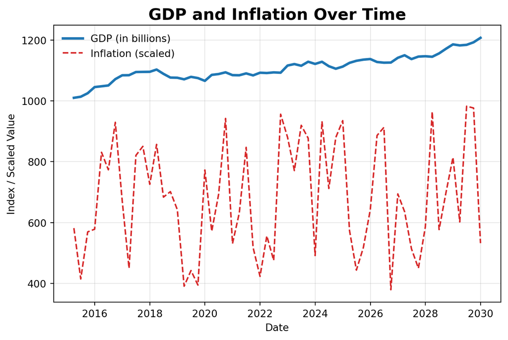

```python
import pandas as pd
import numpy as np
import matplotlib.pyplot as plt

np.random.seed(42)
date_range = pd.date_range("2015-01-01", periods=60, freq="Q")
gdp = 1000 + np.cumsum(np.random.normal(5, 10, len(date_range)))
inflation = np.random.uniform(1.5, 4.0, len(date_range))
df = pd.DataFrame({"date": date_range, "GDP": gdp, "Inflation": inflation})

plt.figure(figsize=(8,5), facecolor="white")
gdp_color = "#1f77b4"        # a strong blue
inflation_color = "#d62728"  # a contrasting red

plt.plot(df["date"], df["GDP"], label="GDP (in billions)", linewidth=2.5, color=gdp_color)
plt.plot(df["date"], df["Inflation"]*250, label="Inflation (scaled)", linestyle="--", color=inflation_color)

plt.title("GDP and Inflation Over Time", fontsize=16, weight="bold")
plt.xlabel("Date")
plt.ylabel("Index / Scaled Value")
plt.legend(frameon=False)
plt.grid(alpha=0.3)
plt.gca().set_facecolor("white")
plt.show()
```

## Bar chart

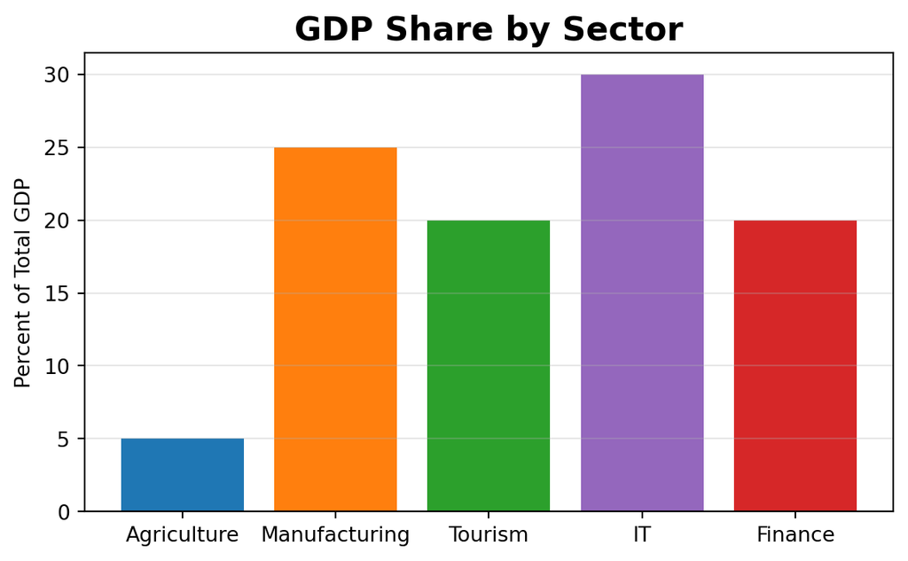

```python
sectors = ["Agriculture", "Manufacturing", "Tourism", "IT", "Finance"]
gdp_share = [5, 25, 20, 30, 20]

plt.figure(figsize=(7,4))
bars = plt.bar(sectors, gdp_share, color=["#1f77b4","#ff7f0e","#2ca02c","#9467bd","#d62728"])
plt.title("GDP Share by Sector", fontsize=16, weight="bold")
plt.ylabel("Percent of Total GDP")
plt.grid(axis="y", alpha=0.3)
plt.show()
```

## Box Plot

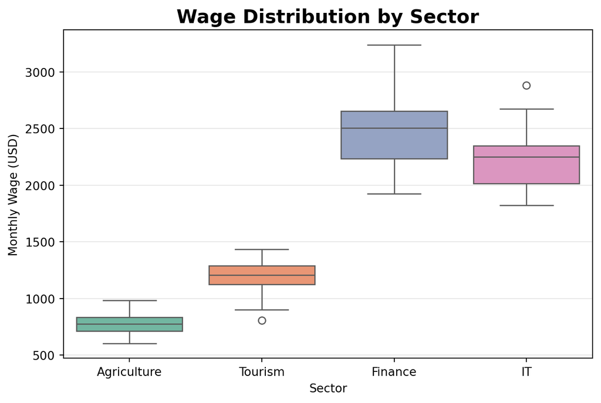

```python
import seaborn as sns
np.random.seed(42)
data = pd.DataFrame({
    "Sector": np.repeat(["Agriculture","Tourism","Finance","IT"], 50),
    "Wage": np.concatenate([
        np.random.normal(800, 100, 50),
        np.random.normal(1200, 150, 50),
        np.random.normal(2500, 300, 50),
        np.random.normal(2200, 250, 50)
    ])
})

plt.figure(figsize=(8,5))
sns.boxplot(data=data, x="Sector", y="Wage", palette="Set2")
plt.title("Wage Distribution by Sector", fontsize=16, weight="bold")
plt.ylabel("Monthly Wage (USD)")
plt.grid(axis="y", alpha=0.3)
plt.show()
```

## Scatter plot

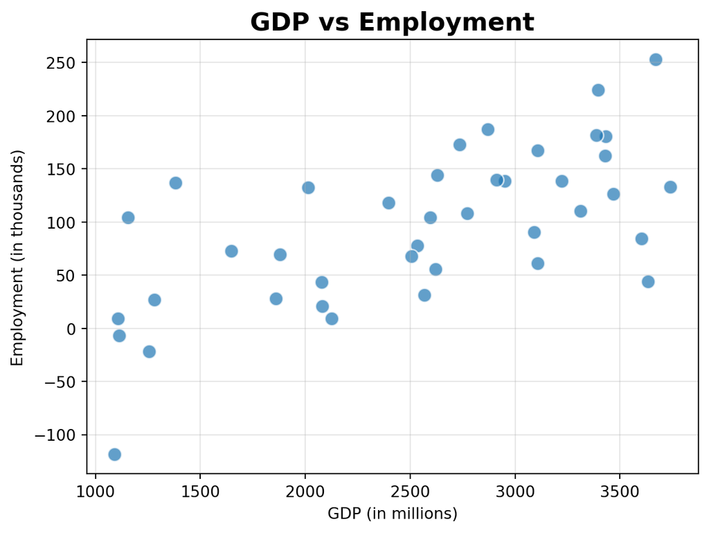

```python
gdp = np.random.uniform(1000, 4000, 40)
employment = gdp*0.04 + np.random.normal(0, 50, 40)

plt.figure(figsize=(7,5))
plt.scatter(gdp, employment, s=80, c="#1f77b4", alpha=0.7, edgecolors="white", linewidths=1)
plt.title("GDP vs Employment", fontsize=16, weight="bold")
plt.xlabel("GDP (in millions)")
plt.ylabel("Employment (in thousands)")
plt.grid(alpha=0.3)
plt.show()
```

## Interactive Plotting with Plotly

```python
import plotly.express as px
import pandas as pd

# Load the dataset
df = px.data.gapminder().query("year == 2007")

# Create an interactive scatter plot
fig = px.scatter(df, x="gdpPercap", y="lifeExp",
                 size="pop", color="continent",
                 hover_name="country", log_x=True,
                 size_max=60)
fig
```

[interactive chart not shown]

## Seaborn Advanced Visualization

```python
import seaborn as sns
import pandas as pd
import matplotlib.pyplot as plt

plt.style.use('seaborn-v0_8')

plt.style.use('seaborn-v0_8')
np.random.seed(42)

# --- Create a fake dataset ---
sectors = ["Agriculture", "Tourism", "Finance", "IT"]
data = pd.DataFrame({
    "Sector": np.repeat(sectors, 80),
    "Wage": np.concatenate([
        np.random.normal(800, 100, 80),
        np.random.normal(1200, 150, 80),
        np.random.normal(2500, 300, 80),
        np.random.normal(2200, 250, 80)
    ]),
    "Hours": np.concatenate([
        np.random.normal(45, 5, 80),
        np.random.normal(42, 4, 80),
        np.random.normal(38, 3, 80),
        np.random.normal(40, 4, 80)
    ])
})

# --- Create figure with subplots ---
fig, (ax1, ax2) = plt.subplots(1, 2, figsize=(15, 6))

# Plot 1: Violin plot for Wage distribution
sns.violinplot(data=data, x="Sector", y="Wage", ax=ax1, palette="Set2", inner="box")
ax1.set_title("Wage Distribution by Sector", fontsize=14, weight="bold")
ax1.set_xlabel("")
ax1.set_ylabel("Monthly Wage (USD)")
ax1.grid(alpha=0.3)

# Plot 2: Box plot for Working Hours
sns.boxplot(data=data, x="Sector", y="Hours", ax=ax2, palette="Set3")
ax2.set_title("Working Hours by Sector", fontsize=14, weight="bold")
ax2.set_xlabel("")
ax2.set_ylabel("Weekly Hours")
ax2.grid(alpha=0.3)

plt.tight_layout()
plt.show()
```

## Seaborn Advanced Visualization

[figure not shown]